# Quick-start for ‘loclm’

Jonathan Rougier

`loclm()` implements local linear regression, using high-level functions. It can handle both numerical and non-numerical variables. Non-numerical variables are converted to factors.

### Top stuff

```r
library(loclm)
show(packageVersion("loclm"))
```

```
#> [1] '1.1.0'
```

```r
show(date())
```

```
#> [1] "Tue Nov 17 16:49:02 2026"
```

Here I’m just setting up a nicer plotting frame.

```r
oldpar <- par(mgp = c(2.5, 0.7, 0), mar = c(4, 4, 2, 0.5), family = "Hershey",
  cex.main = 0.8, cex.axis = 0.8, cex.lab = 0.8, las = 1)
op <- par(no.readonly = TRUE)
```

## Create a dataset

Let’s use the multivariate Banana function variant B from

S. Kok and C. Sandrock, 2009, Locating and Characterizing the Stationary Points of the Extended Rosenbrock Function, *Evolutionary Computing*, **17**(3), pages 437-453.

As the paper explains, variant B is pathological, especially in higher dimensions.

```r
#### d-dimensional Banana function

## (d >= 2 is implied by x)

banana <- function(x) {
  stopifnot(is.vector(x, mode = "numeric"))
  d <- length(x)
  if (d == 1) {
    x <- c(x, 1)
    d <- 2L
  }
  robj <- 0
  for (j in seq_len(d - 1)) {
    robj <- robj + 100 * (x[j]^2 - x[j+1])^2 + (x[j] - 1)^2
  }
  robj
}
```

```r
## make a dataset

set.seed(1234) # for reproducibility, feel free to change

d <- 3
sigma <- 1
X <- matrix(runif(101 * d), ncol = d)
y <- apply(X, 1, banana) + rnorm(nrow(X), sd = sigma)

## here's where we'll predict

newX <- matrix(runif(23 * d), ncol = d)
newy <- apply(newX, 1, banana) # leave off the noise
```

I have left the column-names of `X` and `newX` blank, and they will be assigned default values of `V1`, `V2`, and `V3` inside `loclm()` by `as.data.frame()`. It would be be safer, though, to assign meaningful column-names.

```r
## to assign column names

# nms <- paste0("x", 1:ncol(X)) # or something else
# colnames(X) <- nms
# colnames(newX) <- nms
```

#### All numeric inputs

First, fit the model with the default span.

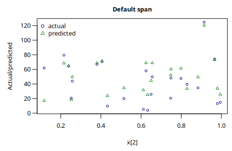

```r
## default span

fit <- loclm(X, y)
pp <- predict(fit, newX)
cex <- 0.6
col <- c("darkblue", "forestgreen")
par(op)
matplot(newX[, 2], cbind(newy, pp), pch = c(1, 2), cex = cex,
  col = col, xlab = "x[2]", ylab = "Actual/predicted",
  main = "Default span")
legend("topleft", c("actual", "predicted"), pch = 1:2, col = col,
  cex = par("cex.axis"), bty = "n")
```

Not great.

## LOO cross-validation to set the span

Now use Leave-One-Out (LOO) cross-validation to set the span. There is a bespoke function `LOO_loclm()`. This always executes sequentially, so that it can be embedded inside a parallel call over multiple values of `span`.

```r
## try different spans, can be executed in parallel

mc <- options("mc.cores")
options(mc.cores = 2L) # or more

span_vals <- c(seq(0.1, 0.2, 0.02), 0.75)
rmse <- parallel::mclapply(span_vals, \(span) {
    loo_resid <- LOO_loclm(fit, span = span)
    sqrt(mean(loo_resid^2))
  }) |> unlist()
show(cbind(span = span_vals, rmse = rmse))
```

```
#>      span      rmse
#> [1,] 0.10  8.568039
#> [2,] 0.12  8.079310
#> [3,] 0.14  7.883803
#> [4,] 0.16  7.232624
#> [5,] 0.18  7.401626
#> [6,] 0.20  7.449551
#> [7,] 0.75 14.292123
```

```r
spanhat <- span_vals[which.min(rmse)]
show(c(span = spanhat))
```

```
#> span
#> 0.16
```

The LOO RMSE has dropped from 14.3 to 7.23. Try predicting with the optimal span.

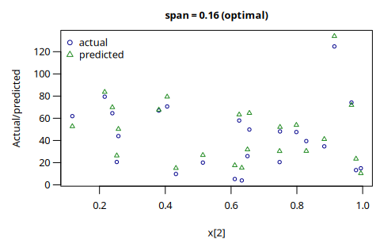

```r
fit <- loclm(X, y, span = spanhat)
pp <- predict(fit, newX)
par(op)
matplot(newX[, 2], cbind(newy, pp), pch = c(1, 2), cex = cex,
  col = col, xlab = "x[2]", ylab = "Actual/predicted",
  main = sprintf("span = %s (optimal)", format(spanhat)))
legend("topleft", c("actual", "predicted"), pch = 1:2, col = col,
  cex = par("cex.axis"), bty = "n")
```

That’s an improvement.

## Factor inputs

Let’s make the first input into a factor.

```r
## first input is a factor

breaks <- seq(0, 1, 0.2)
X <- as.data.frame(X) # into a data.frame
X[[1]] <- factor(LETTERS[cut(X[[1]], breaks)]) # five levels
show(head(X, 10))
```

```
#>    V1         V2        V3
#> 1   A 0.56507611 0.3174938
#> 2   D 0.28025778 0.7678555
#> 3   D 0.20419632 0.5263085
#> 4   D 0.13373890 0.7323019
#> 5   E 0.32568192 0.3076657
#> 6   D 0.15506197 0.4041733
#> 7   A 0.12996214 0.2044024
#> 8   B 0.43553106 0.9856331
#> 9   D 0.03864265 0.5663108
#> 10  C 0.71330156 0.2803751
```

```r
newX <- as.data.frame(newX)
newX[[1]] <- factor(LETTERS[cut(newX[[1]], breaks)])
```

For fitting I should really retune the `span` value, but for speed let’s just crack on.

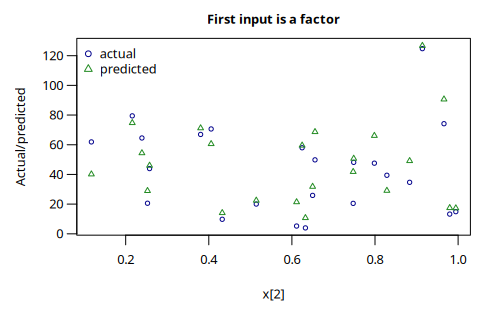

```r
## fit, don't bother to retune

fit <- loclm(X, y, span = spanhat)
pp <- predict(fit, newX)
par(op)
matplot(newX[, 2], cbind(newy, pp), pch = c(1, 2), cex = cex,
  col = col, xlab = "x[2]", ylab = "Actual/predicted",
  main = sprintf("First input is a factor"))
legend("topleft", c("actual", "predicted"), pch = 1:2, col = col,
  cex = par("cex.axis"), bty = "n")
```

Not a disaster.

## Parallel implementation

`predict.loclm()` is currently using `future.apply::future_vapply()` under the hood. The default is sequential (one core). If `newdata` has many rows it will be faster to use multiple cores. The following code is not run, but the rough timings are written in the comments.

```r
## parallel processing -- NOT RUN

if (requireNamespace("future", quietly = TRUE)) {

  big_newX <- do.call("rbind", rep(list(newX), 1E4))
  show(dim(big_newX))
  t1 <- system.time(pp1 <- predict(fit, big_newX))
  show(t1) # 22 sec

  future::plan(future::multisession, workers = 2) # two cores
  t2 <- system.time(pp2 <- predict(fit, big_newX))
  show(t2) # 11 sec
  all.equal(pp1, pp2) # TRUE

  future::plan(future::sequential) # single core
}
```

See `future::plan()` for more details.

## Hat values

In R the generic function `hatvalues()` accesses the diagonal of the hat matrix, and therefore `sum(hatvalues(model))` is the effective number of parameters. In local linear regression this depends on the `span`, with `span = Inf` being linear regression, when the number of parameters is the number of columns in the model matrix, which is one plus the number of variables if all variables are numeric.

```r
## effective number of params

npeff <- sum(hatvalues(fit))
show(npeff)
```

```
#> [1] 57.29056
```

```r
fit_inf <- loclm(X, y, span = Inf)
np_inf <- sum(hatvalues(fit_inf))
show(np_inf) # 7 (hopefully!)
```

```
#> [1] 7
```

The banana function is very non-linear, by construction. For linear regression, `np_inf` should be seven, because `X` has a constant, a five-level factor (four dummy columns), and two numeric variables.`

```r
## reset the session

par(oldpar)
options(mc.cores = mc$mc.cores)
```